# Using a pre-trained convnet

```python
import keras
keras.__version__
```

```
'2.2.5'
```

```python
!sudo pip install pillow
```

```
WARNING: The directory '/home/jovyan/.cache/pip/http' or its parent directory is not owned by the current user and the cache has been disabled. Please check the permissions and owner of that directory. If executing pip with sudo, you may want sudo's -H flag.
WARNING: The directory '/home/jovyan/.cache/pip' or its parent directory is not owned by the current user and caching wheels has been disabled. check the permissions and owner of that directory. If executing pip with sudo, you may want sudo's -H flag.
```

Instantiate the VGG16 model:

```python
from keras.applications import VGG16

conv_base = VGG16(weights='imagenet',
                  include_top=False,
                  input_shape=(150, 150, 3))
```

```python
conv_base.summary()
```

```
Model: "vgg16"
_________________________________________________________________
Layer (type)                 Output Shape              Param #
=================================================================
input_2 (InputLayer)         (None, 150, 150, 3)       0
_________________________________________________________________
block1_conv1 (Conv2D)        (None, 150, 150, 64)      1792
_________________________________________________________________
block1_conv2 (Conv2D)        (None, 150, 150, 64)      36928
_________________________________________________________________
block1_pool (MaxPooling2D)   (None, 75, 75, 64)        0
_________________________________________________________________
block2_conv1 (Conv2D)        (None, 75, 75, 128)       73856
_________________________________________________________________
block2_conv2 (Conv2D)        (None, 75, 75, 128)       147584
_________________________________________________________________
block2_pool (MaxPooling2D)   (None, 37, 37, 128)       0
_________________________________________________________________
block3_conv1 (Conv2D)        (None, 37, 37, 256)       295168
_________________________________________________________________
block3_conv2 (Conv2D)        (None, 37, 37, 256)       590080
_________________________________________________________________
block3_conv3 (Conv2D)        (None, 37, 37, 256)       590080
_________________________________________________________________
block3_pool (MaxPooling2D)   (None, 18, 18, 256)       0
_________________________________________________________________
block4_conv1 (Conv2D)        (None, 18, 18, 512)       1180160
_________________________________________________________________
block4_conv2 (Conv2D)        (None, 18, 18, 512)       2359808
_________________________________________________________________
block4_conv3 (Conv2D)        (None, 18, 18, 512)       2359808
_________________________________________________________________
block4_pool (MaxPooling2D)   (None, 9, 9, 512)         0
_________________________________________________________________
block5_conv1 (Conv2D)        (None, 9, 9, 512)         2359808
_________________________________________________________________
block5_conv2 (Conv2D)        (None, 9, 9, 512)         2359808
_________________________________________________________________
block5_conv3 (Conv2D)        (None, 9, 9, 512)         2359808
_________________________________________________________________
block5_pool (MaxPooling2D)   (None, 4, 4, 512)         0
=================================================================
Total params: 14,714,688
Trainable params: 14,714,688
Non-trainable params: 0
_________________________________________________________________
```

I find the image dataset of fruits, and decide to make the classification of apple and orange. First create the train, test and validation directory and then put the image data into corresponding directory. I used 30 images for each type training, 15 images for validation and 15 images for testing

```python
import os, shutil
```

```python
# The path to the directory where the original
# dataset was uncompressed
original_dataset_dir = 'Fruit_Original'

# The directory where we will
# store our smaller dataset
base_dir = 'Fruits_Data5'
os.mkdir(base_dir)

# Directories for our training,
# validation and test splits
train_dir = os.path.join(base_dir, 'train')
os.mkdir(train_dir)
validation_dir = os.path.join(base_dir, 'validation')
os.mkdir(validation_dir)
test_dir = os.path.join(base_dir, 'test')
os.mkdir(test_dir)

# Directory with our training apple pictures
train_apple_dir = os.path.join(train_dir, 'apple')
os.mkdir(train_apple_dir)

# Directory with our training banana pictures
train_orange_dir = os.path.join(train_dir, 'orange')
os.mkdir(train_orange_dir)

# Directory with our validation apple pictures
validation_apple_dir = os.path.join(validation_dir, 'apple')
os.mkdir(validation_apple_dir)

# Directory with our validation banana pictures
validation_orange_dir = os.path.join(validation_dir, 'orange')
os.mkdir(validation_orange_dir)

# Directory with our test apple pictures
test_apple_dir = os.path.join(test_dir, 'apple')
os.mkdir(test_apple_dir)

# Directory with our test banana pictures
test_orange_dir = os.path.join(test_dir, 'orange')
os.mkdir(test_orange_dir)

# Copy first 30 apple images to train_cats_dir
fnames = ['apple_{}.jpg'.format(i) for i in range(1, 31)]
for fname in fnames:
    src = os.path.join(original_dataset_dir, fname)
    dst = os.path.join(train_apple_dir, fname)
    shutil.copyfile(src, dst)

# Copy next 15 apple images to validation_cats_dir
fnames = ['apple_{}.jpg'.format(i) for i in range(31, 46)]
for fname in fnames:
    src = os.path.join(original_dataset_dir, fname)
    dst = os.path.join(validation_apple_dir, fname)
    shutil.copyfile(src, dst)

# Copy next 15 apple images to test_cats_dir
fnames = ['apple_{}.jpg'.format(i) for i in range(46, 61)]
for fname in fnames:
    src = os.path.join(original_dataset_dir, fname)
    dst = os.path.join(test_apple_dir, fname)
    shutil.copyfile(src, dst)

# Copy first 30 orange images to train_dogs_dir
fnames = ['orange_{}.jpg'.format(i) for i in range(1, 31)]
for fname in fnames:
    src = os.path.join(original_dataset_dir, fname)
    dst = os.path.join(train_orange_dir, fname)
    shutil.copyfile(src, dst)

# Copy next 15 orange images to validation_dogs_dir
fnames = ['orange_{}.jpg'.format(i) for i in range(31, 46)]
for fname in fnames:
    src = os.path.join(original_dataset_dir, fname)
    dst = os.path.join(validation_orange_dir, fname)
    shutil.copyfile(src, dst)

# Copy next 15 orange images to test_dogs_dir
fnames = ['orange_{}.jpg'.format(i) for i in range(46, 61)]
for fname in fnames:
    src = os.path.join(original_dataset_dir, fname)
    dst = os.path.join(test_orange_dir, fname)
    shutil.copyfile(src, dst)
```

Start by simply running instances of the previously-introduced ImageDataGenerator to extract images as Numpy arrays as well as their labels. We will extract features from these images simply by calling the predict method of the conv_base model.

```python
import numpy as np
from keras.preprocessing.image import ImageDataGenerator
from keras.utils.np_utils import to_categorical

base_dir = 'Fruits_Data5'
train_dir = os.path.join(base_dir, 'train')
validation_dir = os.path.join(base_dir, 'validation')
test_dir = os.path.join(base_dir, 'test')

datagen = ImageDataGenerator(rescale=1./255)
batch_size = 20

def extract_features(directory, sample_count):
    features = np.zeros(shape=(sample_count, 4, 4, 512))
    labels = np.zeros(shape=(sample_count))
    generator = datagen.flow_from_directory(
        directory,
        target_size=(150, 150),
        batch_size=batch_size,
        class_mode='binary')
    i = 0
    for inputs_batch, labels_batch in generator:
        features_batch = conv_base.predict(inputs_batch)
        features[i * batch_size : (i + 1) * batch_size] = features_batch
        labels[i * batch_size : (i + 1) * batch_size] = labels_batch
        i += 1
        if i * batch_size >= sample_count:
            # Note that since generators yield data indefinitely in a loop,
            # we must `break` after every image has been seen once.
            break
    return features, labels

train_features, train_labels = extract_features(train_dir, 60)
validation_features, validation_labels = extract_features(validation_dir, 30)
test_features, test_labels = extract_features(test_dir, 30)
```

```
Found 60 images belonging to 2 classes.
Found 30 images belonging to 2 classes.
Found 30 images belonging to 2 classes.
```

The extracted features are currently of shape (samples, 4, 4, 512). We will feed them to a densely-connected classifier, so first we must flatten them to (samples, 8192):

```python
train_features = np.reshape(train_features, (60, 4 * 4 * 512))
validation_features = np.reshape(validation_features, (30, 4 * 4 * 512))
test_features = np.reshape(test_features, (30, 4 * 4 * 512))
```

```python
print(train_features.shape,train_labels.shape)
print(validation_features.shape,validation_labels.shape)
print(test_features.shape,test_labels.shape)
```

```
(60, 8192) (60,)
(30, 8192) (30,)
(30, 8192) (30,)
```

```python
from keras import models
from keras import layers
from keras import optimizers

model = models.Sequential()
model.add(layers.Dense(256, activation='relu', input_dim=4 * 4 * 512))
model.add(layers.Dropout(0.5))
model.add(layers.Dense(1, activation='sigmoid'))

model.compile(optimizer=optimizers.RMSprop(lr=2e-5),
              loss='binary_crossentropy',
              metrics=['acc'])

history = model.fit(train_features, train_labels,
                    epochs=30,
                    batch_size=20,
                    validation_data=(validation_features, validation_labels))
```

```
Train on 60 samples, validate on 30 samples
```

Visualize the loss and accuracy curves:

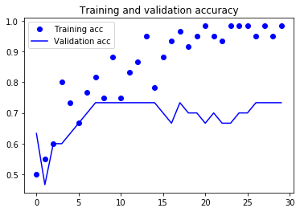

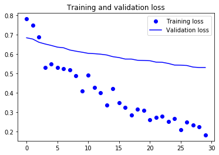

```python
import matplotlib.pyplot as plt

acc = history.history['acc']
val_acc = history.history['val_acc']
loss = history.history['loss']
val_loss = history.history['val_loss']

epochs = range(len(acc))

plt.plot(epochs, acc, 'bo', label='Training acc')
plt.plot(epochs, val_acc, 'b', label='Validation acc')
plt.title('Training and validation accuracy')
plt.legend()

plt.figure()

plt.plot(epochs, loss, 'bo', label='Training loss')
plt.plot(epochs, val_loss, 'b', label='Validation loss')
plt.title('Training and validation loss')
plt.legend()

plt.show()
```

After run the model, I fund the model can only reach the validation accuracy around 0.7. And there is a trend of overfitting, which is because this technique does not leverage data augmentation. So let's take the technique to improve accuracy and reduce overfitting.

# Extending the conv_base model

The technique is to extend the conv_base model and run it end-to-end on the inputs. This technique is slow and expensive, but allows us to leverage data augmentation. This is the mmodel:

```python
from keras import models
from keras import layers

model = models.Sequential()
model.add(conv_base)
model.add(layers.Flatten())
model.add(layers.Dense(256, activation='relu'))
model.add(layers.Dense(1, activation='sigmoid'))
```

```python
model.summary()
```

```
Model: "sequential_4"
_________________________________________________________________
Layer (type)                 Output Shape              Param #
=================================================================
vgg16 (Model)                (None, 4, 4, 512)         14714688
_________________________________________________________________
flatten_2 (Flatten)          (None, 8192)              0
_________________________________________________________________
dense_7 (Dense)              (None, 256)               2097408
_________________________________________________________________
dense_8 (Dense)              (None, 1)                 257
=================================================================
Total params: 16,812,353
Trainable params: 16,812,353
Non-trainable params: 0
_________________________________________________________________
```

Before compiling and training, we should freeze the convolutional base to prevent the weights from getting updated during training. To do this, trainable attribute needs to be set to False:

```python
print('This is the number of trainable weights '
      'before freezing the conv base:', len(model.trainable_weights))
```

```
This is the number of trainable weights before freezing the conv base: 30
```

```python
conv_base.trainable = False
```

```python
print('This is the number of trainable weights '
      'after freezing the conv base:', len(model.trainable_weights))
```

```
This is the number of trainable weights after freezing the conv base: 4
```

With this setup, only the weights from the two Dense layers that we added will be trained. That's a total of four weight tensors: two per layer. Star training our model, with the same data augmentation configuration:

```python
from keras.preprocessing.image import ImageDataGenerator

train_datagen = ImageDataGenerator(
      rescale=1./255,
      rotation_range=40,
      width_shift_range=0.2,
      height_shift_range=0.2,
      shear_range=0.2,
      zoom_range=0.2,
      horizontal_flip=True,
      fill_mode='nearest')

# Note that the validation data should not be augmented!
test_datagen = ImageDataGenerator(rescale=1./255)

train_generator = train_datagen.flow_from_directory(
        # This is the target directory
        train_dir,
        # All images will be resized to 150x150
        target_size=(150, 150),
        batch_size=20,
        # Since we use binary_crossentropy loss, we need binary labels
        class_mode='binary')

validation_generator = test_datagen.flow_from_directory(
        validation_dir,
        target_size=(150, 150),
        batch_size=20,
        class_mode='binary')

model.compile(loss='binary_crossentropy',
              optimizer=optimizers.RMSprop(lr=2e-5),
              metrics=['acc'])

history = model.fit_generator(
      train_generator,
      steps_per_epoch=4,
      epochs=30,
      validation_data=validation_generator,
      validation_steps=2,
      verbose=2)
```

```
Found 60 images belonging to 2 classes.
Found 30 images belonging to 2 classes.
 - 7s - loss: 0.6874 - acc: 0.5750 - val_loss: 0.6711 - val_acc: 0.5667
 - 6s - loss: 0.6552 - acc: 0.6375 - val_loss: 0.6480 - val_acc: 0.7000
 - 7s - loss: 0.6046 - acc: 0.7125 - val_loss: 0.6389 - val_acc: 0.6667
 - 6s - loss: 0.5900 - acc: 0.7125 - val_loss: 0.6236 - val_acc: 0.6333
 - 6s - loss: 0.5735 - acc: 0.7125 - val_loss: 0.6019 - val_acc: 0.7667
 - 6s - loss: 0.5593 - acc: 0.7125 - val_loss: 0.5925 - val_acc: 0.7333
 - 6s - loss: 0.5337 - acc: 0.8250 - val_loss: 0.5814 - val_acc: 0.7333
 - 6s - loss: 0.5043 - acc: 0.8125 - val_loss: 0.5630 - val_acc: 0.8000
 - 7s - loss: 0.5241 - acc: 0.7500 - val_loss: 0.5645 - val_acc: 0.7333
 - 6s - loss: 0.4999 - acc: 0.8375 - val_loss: 0.5704 - val_acc: 0.6333
 - 6s - loss: 0.4527 - acc: 0.8875 - val_loss: 0.5499 - val_acc: 0.7667
 - 7s - loss: 0.4803 - acc: 0.8625 - val_loss: 0.5356 - val_acc: 0.8000
 - 6s - loss: 0.4557 - acc: 0.8375 - val_loss: 0.5240 - val_acc: 0.8000
 - 6s - loss: 0.4428 - acc: 0.8625 - val_loss: 0.5129 - val_acc: 0.8000
 - 7s - loss: 0.4090 - acc: 0.9000 - val_loss: 0.5072 - val_acc: 0.8000
 - 6s - loss: 0.3830 - acc: 0.9250 - val_loss: 0.5133 - val_acc: 0.8000
 - 6s - loss: 0.4210 - acc: 0.8250 - val_loss: 0.4917 - val_acc: 0.8000
 - 7s - loss: 0.3930 - acc: 0.8875 - val_loss: 0.4929 - val_acc: 0.8000
 - 6s - loss: 0.3903 - acc: 0.8875 - val_loss: 0.4875 - val_acc: 0.8000
 - 6s - loss: 0.3850 - acc: 0.9125 - val_loss: 0.4810 - val_acc: 0.8000
 - 7s - loss: 0.3664 - acc: 0.8875 - val_loss: 0.4645 - val_acc: 0.8000
 - 6s - loss: 0.3490 - acc: 0.9125 - val_loss: 0.4536 - val_acc: 0.8000
 - 6s - loss: 0.3416 - acc: 0.9125 - val_loss: 0.4464 - val_acc: 0.8000
 - 7s - loss: 0.3388 - acc: 0.9125 - val_loss: 0.4515 - val_acc: 0.8000
 - 6s - loss: 0.3505 - acc: 0.9000 - val_loss: 0.4532 - val_acc: 0.8000
 - 6s - loss: 0.3301 - acc: 0.9250 - val_loss: 0.4531 - val_acc: 0.8000
 - 7s - loss: 0.3143 - acc: 0.9375 - val_loss: 0.4356 - val_acc: 0.8000
 - 6s - loss: 0.3327 - acc: 0.9375 - val_loss: 0.4282 - val_acc: 0.8000
 - 6s - loss: 0.3123 - acc: 0.9500 - val_loss: 0.4252 - val_acc: 0.7667
 - 6s - loss: 0.2813 - acc: 0.9375 - val_loss: 0.4243 - val_acc: 0.7667
```

```python
model.save('fruits_classification_3.h5')
```

Visualize the loss and accuracy curves:

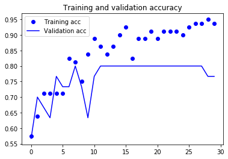

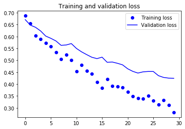

```python
acc = history.history['acc']
val_acc = history.history['val_acc']
loss = history.history['loss']
val_loss = history.history['val_loss']

epochs = range(len(acc))

plt.plot(epochs, acc, 'bo', label='Training acc')
plt.plot(epochs, val_acc, 'b', label='Validation acc')
plt.title('Training and validation accuracy')
plt.legend()

plt.figure()

plt.plot(epochs, loss, 'bo', label='Training loss')
plt.plot(epochs, val_loss, 'b', label='Validation loss')
plt.title('Training and validation loss')
plt.legend()

plt.show()
```

As you can see, this time, the validation accuracy is around 0.8, better than the previous one.

# Fine-tuning

```python
conv_base.summary()
```

```
Model: "vgg16"
_________________________________________________________________
Layer (type)                 Output Shape              Param #
=================================================================
input_2 (InputLayer)         (None, 150, 150, 3)       0
_________________________________________________________________
block1_conv1 (Conv2D)        (None, 150, 150, 64)      1792
_________________________________________________________________
block1_conv2 (Conv2D)        (None, 150, 150, 64)      36928
_________________________________________________________________
block1_pool (MaxPooling2D)   (None, 75, 75, 64)        0
_________________________________________________________________
block2_conv1 (Conv2D)        (None, 75, 75, 128)       73856
_________________________________________________________________
block2_conv2 (Conv2D)        (None, 75, 75, 128)       147584
_________________________________________________________________
block2_pool (MaxPooling2D)   (None, 37, 37, 128)       0
_________________________________________________________________
block3_conv1 (Conv2D)        (None, 37, 37, 256)       295168
_________________________________________________________________
block3_conv2 (Conv2D)        (None, 37, 37, 256)       590080
_________________________________________________________________
block3_conv3 (Conv2D)        (None, 37, 37, 256)       590080
_________________________________________________________________
block3_pool (MaxPooling2D)   (None, 18, 18, 256)       0
_________________________________________________________________
block4_conv1 (Conv2D)        (None, 18, 18, 512)       1180160
_________________________________________________________________
block4_conv2 (Conv2D)        (None, 18, 18, 512)       2359808
_________________________________________________________________
block4_conv3 (Conv2D)        (None, 18, 18, 512)       2359808
_________________________________________________________________
block4_pool (MaxPooling2D)   (None, 9, 9, 512)         0
_________________________________________________________________
block5_conv1 (Conv2D)        (None, 9, 9, 512)         2359808
_________________________________________________________________
block5_conv2 (Conv2D)        (None, 9, 9, 512)         2359808
_________________________________________________________________
block5_conv3 (Conv2D)        (None, 9, 9, 512)         2359808
_________________________________________________________________
block5_pool (MaxPooling2D)   (None, 4, 4, 512)         0
=================================================================
Total params: 14,714,688
Trainable params: 0
Non-trainable params: 14,714,688
_________________________________________________________________
```

Only fine-tune the top 2 to 3 layers in the convolutional base, using RMSprop optimizer with a very low learning rate:

```python
conv_base.trainable = True

set_trainable = False
for layer in conv_base.layers:
    if layer.name == 'block5_conv1':
        set_trainable = True
    if set_trainable:
        layer.trainable = True
    else:
        layer.trainable = False
```

```python
model.compile(loss='binary_crossentropy',
              optimizer=optimizers.RMSprop(lr=1e-5),
              metrics=['acc'])

history = model.fit_generator(
      train_generator,
      steps_per_epoch=4,
      epochs=100,
      validation_data=validation_generator,
      validation_steps=2)
```

```python
model.save('fruits_classification_4.h5')
```

Visualize the loos and accuracy again:

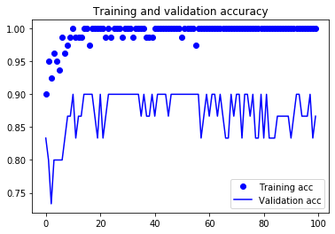

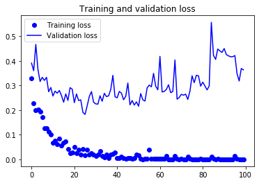

```python
acc = history.history['acc']
val_acc = history.history['val_acc']
loss = history.history['loss']
val_loss = history.history['val_loss']

epochs = range(len(acc))

plt.plot(epochs, acc, 'bo', label='Training acc')
plt.plot(epochs, val_acc, 'b', label='Validation acc')
plt.title('Training and validation accuracy')
plt.legend()

plt.figure()

plt.plot(epochs, loss, 'bo', label='Training loss')
plt.plot(epochs, val_loss, 'b', label='Validation loss')
plt.title('Training and validation loss')
plt.legend()

plt.show()
```

Smooth the plots by replacing every loss and accuracy with exponential moving averages of these quantities:

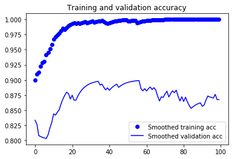

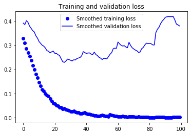

```python
def smooth_curve(points, factor=0.8):
  smoothed_points = []
  for point in points:
    if smoothed_points:
      previous = smoothed_points[-1]
      smoothed_points.append(previous * factor + point * (1 - factor))
    else:
      smoothed_points.append(point)
  return smoothed_points

plt.plot(epochs,
         smooth_curve(acc), 'bo', label='Smoothed training acc')
plt.plot(epochs,
         smooth_curve(val_acc), 'b', label='Smoothed validation acc')
plt.title('Training and validation accuracy')
plt.legend()

plt.figure()

plt.plot(epochs,
         smooth_curve(loss), 'bo', label='Smoothed training loss')
plt.plot(epochs,
         smooth_curve(val_loss), 'b', label='Smoothed validation loss')
plt.title('Training and validation loss')
plt.legend()

plt.show()
```

```python
test_generator = test_datagen.flow_from_directory(
        test_dir,
        target_size=(150, 150),
        batch_size=20,
        class_mode='binary')

test_loss, test_acc = model.evaluate_generator(test_generator, steps=2)
print('test acc:', test_acc)
```

```
Found 30 images belonging to 2 classes.
test acc: 0.8999999761581421
```

After smooth the plot and do the validation on the test data, the result improves a lot. Although there is still s trend of overfitting, maybe due to the very small dataset I choose(only 30 images for training), the accuracy is actually improved. I found the validation accuracy is around 0.89, close to 0.9. That is a significant improvement from the previous model.